# DisturbanceNotebook

# Earning

Age - количественная переменная и Earning - ранговая переменные. Для нахождения связи будем использовать корреляцию Кендалла  
H0 - связи между переменными нет  
H1 - связь между переменными есть

```r
age_Earning_corr <- get_kendall_cor(finished_data$Age, as.numeric(finished_data$Earning))
age_Earning_corr
```

```
##        Coef ObservedT   TableT IsNullHypotesisTrue
## 1 0.2886179  2.861144 1.959964               FALSE
```

```r
corr_matrix['Age', 'Earning'] = get_val(age_Earning_corr)
corr_matrix['Earning', 'Age'] = get_val(age_Earning_corr)
```

# PersonalDisturbance

Н0 - связи нет  
H1 - связь есть

```r
age_PersonalDisturbance_corr <- get_biser_coeff_abs(finished_data$Age, finished_data$PersonalDisturbance)
age_PersonalDisturbance_corr
```

```
##         Coef    t_obs  t_table IsNullHypotesisTrue
## 1 -0.1708121 1.162933 1.679427                TRUE
```

Как видим |t наблюдаемое| меньше |t табличного|, а значит нулевая гипотеза принимается.

```r
corr_matrix['Age', 'PersonalDisturbance'] = get_val(age_PersonalDisturbance_corr)
corr_matrix['PersonalDisturbance', 'Age'] = get_val(age_PersonalDisturbance_corr)
```

# IsDisturbed

Н0 - связи нет  
H1 - связь есть

```r
age_dist <- get_biser_coeff_abs(finished_data$Age, finished_data$IsDisturbed)
print(age_dist)
```

```
##          Coef     t_obs  t_table IsNullHypotesisTrue
## 1 -0.08387318 0.5646279 1.679427                TRUE
```

Как видим |t наблюдаемое| меньше |t табличного|, а значит нулевая гипотеза принимается.

```r
corr_matrix['Age', 'IsDisturbed'] = get_val(age_dist)
corr_matrix['IsDisturbed', 'Age'] = get_val(age_dist)
```

## Sex

# IsStudying

Sex - дихотомическая, IsStudying - дихотимческая. Для измерения степени связи между переменными будем использовать коэффициенты ассоциации и контингенции.  
Коэффициент ассоциации:

```r
sex_IsStudying_df <- table(data.frame(finished_data$Sex, finished_data$IsStudying))
sex_IsStudying_assoc <- assoc(sex_IsStudying_df)
sex_IsStudying_assoc
```

```
## [1] 0.07317073
```

Коэффициент ассоциации слишком мал. Коэффициент контингенции вычислять смысла нет. Связи между факторами обучения и пола практическ3и нет.

```r
corr_matrix['Sex', 'IsStudying'] = sex_IsStudying_assoc
corr_matrix['IsStudying', 'Sex'] = sex_IsStudying_assoc
```

# IsWorking

Sex - дихотомическая, IsWorking - дихотимческая. Для измерения степени связи между переменными будем использовать коэффициенты ассоциации и контингенции.  
Коэффициент ассоциации:

```r
sex_IsWorking_df <- table(data.frame(finished_data$Sex, finished_data$IsWorking))
sex_IsWorking_assoc <- assoc(sex_IsWorking_df)
sex_IsWorking_assoc
```

```
## [1] 0.1428571
```

Коэффициент ассоциации слишком мал. Коэффициент контингенции вычислят смысла нет. Связи между факторами работы и пола практически нет.

```r
corr_matrix['Sex', 'IsWorking'] = sex_IsWorking_assoc
corr_matrix['IsWorking', 'Sex'] = sex_IsWorking_assoc
```

# Music

Sex - дихотомическая, Music - номинальная. Для измерения степени связи между переменными будем использовать коэффициент взаимной сопряжённости.  
H0 - связи нет.  
H1 - связь есть.

```r
sex_Music_df <- data.frame(finished_data$Sex, finished_data$Music)
sex_Music_corr <- pearson.contingence(table(sex_Music_df), length(sex_Music_df[,1]))
sex_Music_corr
```

```
##        Coef Chi_Sq_obs Chi_Sq_table IsNullHypotesisTrue
## 1 0.2784238   3.949602       31.439               FALSE
```

```r
corr_matrix['Sex', 'Music'] = get_val(sex_Music_corr)
corr_matrix['Music', 'Sex'] = get_val(sex_Music_corr)
```

# FreeTime

FreeTime - количественная переменная, Sex - дихотомическая. Найдём степень связи при помощи бисериального коэффициента Пирсона:  
H0 - связи между переменными нет  
H1 - связь между переменными есть

```r
sex_FreeTime_corr <- get_biser_coeff_abs(finished_data$FreeTime, finished_data$Sex)
sex_FreeTime_corr
```

```
##        Coef    t_obs  t_table IsNullHypotesisTrue
## 1 0.3527845 2.529164 1.679427               FALSE
```

```r
corr_matrix['Sex', 'FreeTime'] = get_val(sex_FreeTime_corr)
corr_matrix['FreeTime', 'Sex'] = get_val(sex_FreeTime_corr)
```

# SleepTime

SleepTime - количественная переменная, Sex - дихотомическая. Найдём степень связи при помощи бисериального коэффициента Пирсона:  
H0 - связи между переменными нет  
H1 - связь между переменными есть

```r
sex_SleepTime_corr <- get_biser_coeff_abs(finished_data$SleepTime, finished_data$Sex)
sex_SleepTime_corr
```

```
##       Coef    t_obs  t_table IsNullHypotesisTrue
## 1 0.228469 1.574254 1.679427                TRUE
```

```r
corr_matrix['Sex', 'SleepTime'] = get_val(sex_SleepTime_corr)
corr_matrix['SleepTime', 'Sex'] = get_val(sex_SleepTime_corr)
```

# NervousPeriod

NervousPeriod - ранговая переменная, Sex - дихотомическая. Найдём степень связи при помощи рангово-бисериального коэффициента Пирсона:  
H0 - связи между переменными нет  
H1 - связь между переменными есть

```r
sex_NervousPeriod_corr <- get_rank_biser_coef_pearson(finished_data, "NervousPeriod", "Sex")
sex_NervousPeriod_corr
```

```
##        Coef ObservedT    TableT IsNullHypotesisTrue
## 1 0.2563636    1.7792 -2.014103                TRUE
```

```r
corr_matrix['Sex', 'NervousPeriod'] = get_val(sex_NervousPeriod_corr)
corr_matrix['NervousPeriod', 'Sex'] = get_val(sex_NervousPeriod_corr)
```

# ChronicWeak

Sex - дихотомическая, ChronicWeak - дихотимческая. Для измерения степени связи между переменными будем использовать коэффициенты ассоциации и контингенции.  
Коэффициент ассоциации:

```r
sex_ChronicWeak_df <- table(data.frame(finished_data$Sex, finished_data$ChronicWeak))
sex_ChronicWeak_assoc <- assoc(sex_ChronicWeak_df)
sex_ChronicWeak_assoc
```

```
## [1] -0.01886792
```

```r
corr_matrix['Sex', 'ChronicWeak'] = sex_ChronicWeak_assoc
corr_matrix['ChronicWeak', 'Sex'] = sex_ChronicWeak_assoc
```

# Earning

Earning - ранговая переменная, Sex - дихотомическая. Найдём степень связи при помощи рангово-бисериального коэффициента Пирсона:  
H0 - связи между переменными нет  
H1 - связь между переменными есть

```r
sex_Earning_corr <- get_rank_biser_coef_pearson(finished_data, "Earning", "Sex")
sex_Earning_corr
```

```
##        Coef ObservedT    TableT IsNullHypotesisTrue
## 1 0.2018182  1.382281 -2.014103                TRUE
```

# IsDisturbed

Для нахождения связи применим коэффициенты ассоциации и контингенции

```r
assoc(table(subset(finished_data, select=c(Sex, IsDisturbed))))
```

```
## [1] 0.5104895
```

```r
sex_IsDisturbed_conting <- conting(table(subset(finished_data, select=c(Sex, IsDisturbed))))
sex_IsDisturbed_conting
```

```
## [1] 0.269908
```

Точного ответа о связи между полом и тревожностью дать нельзя, так как коэффициент ассоциации немногим больше 0.5, а коэффициент контингенции немногим меньше 0.3.

```r
corr_matrix['Sex', 'IsDisturbed'] = sex_IsDisturbed_conting
corr_matrix['IsDisturbed', 'Sex'] = sex_IsDisturbed_conting
```

# PersonalDisturbance

Для нахождения связи применим коэффициенты ассоциации и контингенции

```r
assoc(table(subset(finished_data, select=c(Sex, PersonalDisturbance))))
```

```
## [1] 0.3023256
```

```r
sex_PersonalDisturbance_conting <- conting(table(subset(finished_data, select=c(Sex, PersonalDisturbance))))
sex_PersonalDisturbance_conting
```

```
## [1] 0.1352407
```

```r
corr_matrix['Sex', 'PersonalDisturbance'] = sex_PersonalDisturbance_conting
corr_matrix['PersonalDisturbance', 'Sex'] = sex_PersonalDisturbance_conting
```

## IsStudying

# IsWorking

IsStudying - дихотомическая, IsWorking - дихотимческая. Для измерения степени связи между переменными будем использовать коэффициенты ассоциации и контингенции.  
Коэффициент ассоциации:

```r
isStudying_IsWorking_df <- table(data.frame(finished_data$IsStudying, finished_data$IsWorking))
assoc(isStudying_IsWorking_df)
```

```
## [1] -0.4769231
```

Коэффициент ассоциации близок к 0.5. Коэффициент контингенции:

```r
isStudying_IsWorking_cont <- conting(isStudying_IsWorking_df)
isStudying_IsWorking_cont
```

```
## [1] -0.1691717
```

Коэффициент контингенции меньше 0.3, а значит связи между факторами обучения и работы нет

```r
corr_matrix['IsStudying', 'IsWorking'] = isStudying_IsWorking_cont
corr_matrix['IsWorking', 'IsStudying'] = isStudying_IsWorking_cont
```

# Music

IsStudying - дихотомическая, Music - номинальная. Для измерения степени связи между переменными будем использовать коэффициент взаимной сопряжённости.  
H0 - связи нет.  
H1 - связь есть.

```r
isStudying_Music_df <- data.frame(finished_data$IsStudying, finished_data$Music)
isStudying_Music_corr <- pearson.contingence(table(isStudying_Music_df), length(isStudying_Music_df[,1]))
isStudying_Music_corr
```

```
##        Coef Chi_Sq_obs Chi_Sq_table IsNullHypotesisTrue
## 1 0.3301489   5.749619       31.439               FALSE
```

```r
corr_matrix['IsStudying', 'Music'] = get_val(isStudying_Music_corr)
corr_matrix['Music', 'IsStudying'] = get_val(isStudying_Music_corr)
```

# FreeTime

FreeTime - количественная переменная, IsStudying - дихотомическая. Найдём степень связи при помощи бисериального коэффициента Пирсона:  
H0 - связи между переменными нет  
H1 - связь между переменными есть

```r
isStudying_FreeTime_corr <- get_biser_coeff_abs(finished_data$FreeTime, finished_data$IsStudying)
isStudying_FreeTime_corr
```

```
##        Coef     t_obs  t_table IsNullHypotesisTrue
## 1 0.1270171 0.8590139 1.679427                TRUE
```

```r
corr_matrix['IsStudying', 'FreeTime'] = get_val(isStudying_FreeTime_corr)
corr_matrix['FreeTime', 'IsStudying'] = get_val(isStudying_FreeTime_corr)
```

# SleepTime

SleepTime - количественная переменная, IsStudying - дихотомическая. Найдём степень связи при помощи бисериального коэффициента Пирсона:  
H0 - связи между переменными нет  
H1 - связь между переменными есть

```r
isStudying_SleepTime_corr <- get_biser_coeff_abs(finished_data$SleepTime, finished_data$IsStudying)
isStudying_SleepTime_corr
```

```
##        Coef   t_obs  t_table IsNullHypotesisTrue
## 1 0.2128114 1.46105 1.679427                TRUE
```

```r
corr_matrix['IsStudying', 'SleepTime'] = get_val(isStudying_SleepTime_corr)
corr_matrix['SleepTime', 'IsStudying'] = get_val(isStudying_SleepTime_corr)
```

# NervousPeriod

NervousPeriod - ранговая переменная, IsStudying - дихотомическая. Найдём степень связи при помощи рангово-бисериального коэффициента Пирсона:  
H0 - связи между переменными нет  
H1 - связь между переменными есть

```r
isStudying_NervousPeriod_corr <- get_rank_biser_coef_pearson(finished_data, "NervousPeriod", "IsStudying")
isStudying_NervousPeriod_corr
```

```
##        Coef ObservedT    TableT IsNullHypotesisTrue
## 1 0.4227642  3.129402 -2.014103               FALSE
```

```r
corr_matrix['IsStudying', 'NervousPeriod'] = get_val(isStudying_NervousPeriod_corr)
corr_matrix['NervousPeriod', 'IsStudying'] = get_val(isStudying_NervousPeriod_corr)
```

# ChronicWeak

IsStudying - дихотомическая, ChronicWeak - дихотимческая. Для измерения степени связи между переменными будем использовать коэффициенты ассоциации и контингенции.  
Коэффициент ассоциации:

```r
isStudying_ChronicWeak_df <- table(data.frame(finished_data$IsStudying, finished_data$ChronicWeak))
assoc(isStudying_ChronicWeak_df)
```

```
## [1] -0.5522388
```

Коэффициент ассоциации по модулю больше 0.5. Коэффициент контингенции:

```r
isStudying_ChronicWeak_cont <- conting(isStudying_ChronicWeak_df)
isStudying_ChronicWeak_cont
```

```
## [1] -0.2045542
```

Коэффициент контингенции меньше 0.3, а значит степень связи между факторами не подтверждена

```r
corr_matrix['IsStudying', 'ChronicWeak'] = isStudying_ChronicWeak_cont
corr_matrix['ChronicWeak', 'IsStudying'] = isStudying_ChronicWeak_cont
```

# Earning

Earning - ранговая переменная, IsStudying - дихотомическая. Найдём степень связи при помощи рангово-бисериального коэффициента Пирсона:  
H0 - связи между переменными нет  
H1 - связь между переменными есть

```r
isStudying_Earning_corr <- get_rank_biser_coef_pearson(finished_data, "NervousPeriod", "Earning")
isStudying_Earning_corr
```

```
##        Coef ObservedT    TableT IsNullHypotesisTrue
## 1 0.2216312  1.524665 -2.014103                TRUE
```

```r
corr_matrix['IsStudying', 'Earning'] = get_val(isStudying_Earning_corr)
corr_matrix['Earning', 'IsStudying'] = get_val(isStudying_Earning_corr)
```

# IsDisturbed

Для нахождение связи применим коэффициенты ассоциации и контингенции

```r
assoc(table(subset(finished_data, select=c(IsStudying, IsDisturbed))))
```

```
## [1] -0.5929204
```

```r
isStudying_IsDisturbed_cont <- conting(table(subset(finished_data, select=c(IsStudying, IsDisturbed))))
```

```r
corr_matrix['IsStudying', 'IsDisturbed'] = isStudying_IsDisturbed_cont
corr_matrix['IsDisturbed', 'IsStudying'] = isStudying_IsDisturbed_cont
```

# PersonalDisturbance

Для нахождение связи применим коэффициенты ассоциации и контингенции

```r
assoc(table(subset(finished_data, select=c(IsStudying, PersonalDisturbance))))
```

```
## [1] -0.2941176
```

```r
isStudying_PersonalDisturbance_cont <- conting(table(subset(finished_data, select=c(IsStudying, PersonalDisturbance))))
```

```r
corr_matrix['IsStudying', 'PersonalDisturbance'] = isStudying_PersonalDisturbance_cont
corr_matrix['PersonalDisturbance', 'IsStudying'] = isStudying_PersonalDisturbance_cont
```

## IsWorking

# Music

IsWorking - дихотомическая, Music - номинальная. Для измерения степени связи между переменными будем использовать коэффициент взаимной сопряжённости.  
H0 - связи нет.  
H1 - связь есть.

```r
isWorking_Music_df <- data.frame(finished_data$IsWorking, finished_data$Music)
isWorking_Music_corr <- pearson.contingence(table(isWorking_Music_df), length(isWorking_Music_df[,1]))
isWorking_Music_corr
```

```
##        Coef Chi_Sq_obs Chi_Sq_table IsNullHypotesisTrue
## 1 0.1843489   1.653465       31.439               FALSE
```

Между фактором обучения и прослушиванием музыки есть слабая связь. Наблюдаемое значение хи-2 меньше табличного, а значит нулевая гипотеза отвергается.

```r
corr_matrix['IsWorking', 'Music'] = get_val(isWorking_Music_corr)
corr_matrix['Music', 'IsWorking'] = get_val(isWorking_Music_corr)
```

# FreeTime

FreeTime - количественная переменная, IsWorking - дихотомическая. Найдём степень связи при помощи бисериального коэффициента Пирсона:  
H0 - связи между переменными нет  
H1 - связь между переменными есть

```r
isWorking_FreeTime_corr <- get_biser_coeff_abs(finished_data$FreeTime, finished_data$IsWorking)
isWorking_FreeTime_corr
```

```
##          Coef     t_obs  t_table IsNullHypotesisTrue
## 1 -0.08072064 0.5432633 1.679427                TRUE
```

Как можно заметить, связь между полом опрошенных и временем сна практически отсутствует. Наблюдаемое t входит в доверительный интервал, значит гипотеза об отсутствии связи принимается

```r
corr_matrix['IsWorking', 'FreeTime'] = get_val(isWorking_FreeTime_corr)
corr_matrix['FreeTime', 'IsWorking'] = get_val(isWorking_FreeTime_corr)
```

# SleepTime

SleepTime - количественная переменная, IsWorking - дихотомическая. Найдём степень связи при помощи бисериального коэффициента Пирсона:  
H0 - связи между переменными нет  
H1 - связь между переменными есть

```r
isWorking_SleepTime_corr <- get_biser_coeff_abs(finished_data$SleepTime, finished_data$IsWorking)
isWorking_SleepTime_corr
```

```
##        Coef    t_obs  t_table IsNullHypotesisTrue
## 1 0.1478575 1.002881 1.679427                TRUE
```

Как можно заметить, связь между полом опрошенных и временем сна слабая. Наблюдаемое t входит в доверительный интервал, значит гипотеза об отсутствии связи принимается

```r
corr_matrix['IsWorking', 'SleepTime'] = get_val(isWorking_SleepTime_corr)
corr_matrix['SleepTime', 'IsWorking'] = get_val(isWorking_SleepTime_corr)
```

# NervousPeriod

NervousPeriod - ранговая переменная, IsWorking - дихотомическая. Найдём степень связи при помощи рангово-бисериального коэффициента Пирсона:  
H0 - связи между переменными нет  
H1 - связь между переменными есть

```r
isWorking_NervousPeriod_corr <- get_rank_biser_coef_pearson(finished_data, "NervousPeriod", "IsWorking")
isWorking_NervousPeriod_corr
```

```
##         Coef ObservedT    TableT IsNullHypotesisTrue
## 1 0.09340659 0.6293419 -2.014103                TRUE
```

```r
corr_matrix['IsWorking', 'NervousPeriod'] = get_val(isWorking_NervousPeriod_corr)
corr_matrix['NervousPeriod', 'IsWorking'] = get_val(isWorking_NervousPeriod_corr)
```

# ChronicWeak

IsWorking - дихотомическая, ChronicWeak - дихотимческая. Для измерения степени связи между переменными будем использовать коэффициенты ассоциации и контингенции.  
Коэффициент ассоциации:

```r
isWorking_ChronicWeak_df <- table(data.frame(finished_data$IsWorking, finished_data$ChronicWeak))
assoc(isWorking_ChronicWeak_df)
```

```
## [1] 0.4244604
```

Коэффициент ассоциации по модулю чуть меньше 0.5. Коэффициент контингенции:

```r
isWorking_ChronicWeak_cont <- conting(isWorking_ChronicWeak_df)
```

Коэффициент контингенции меньше 0.3, а значит связи между факторами нет

```r
corr_matrix['IsWorking', 'ChronicWeak'] = isWorking_ChronicWeak_cont
corr_matrix['ChronicWeak', 'IsWorking'] = isWorking_ChronicWeak_cont
```

# Earning

Earning - ранговая переменная, IsWorking - дихотомическая. Найдём степень связи при помощи рангово-бисериального коэффициента Пирсона:  
H0 - связи между переменными нет  
H1 - связь между переменными есть

```r
isWorking_Earning_corr <- get_rank_biser_coef_pearson(finished_data, "NervousPeriod", "Earning")
isWorking_Earning_corr
```

```
##        Coef ObservedT    TableT IsNullHypotesisTrue
## 1 0.2216312  1.524665 -2.014103                TRUE
```

```r
corr_matrix['IsWorking', 'Earning'] = get_val(isWorking_Earning_corr)
corr_matrix['Earning', 'IsWorking'] = get_val(isWorking_Earning_corr)
```

# IsDisturbed

Для нахождения связи применим коэффициенты ассоциации и контингенции

```r
assoc(table(subset(finished_data, select=c(IsWorking, IsDisturbed))))
```

```
## [1] 0.2631579
```

```r
isWorking_IsDisturbed_cont <- conting(table(subset(finished_data, select=c(IsWorking, IsDisturbed))))
```

Связи между работой и тревожностью нет вовсе, так как коэффициент ассоциации по модулю меньше 0.5, а коэффициент контингенции по модулю меньше 0.3.

```r
corr_matrix['IsWorking', 'IsDisturbed'] = isWorking_IsDisturbed_cont
corr_matrix['IsDisturbed', 'IsWorking'] = isWorking_IsDisturbed_cont
```

# PersonalDisturbance

Для нахождения связи применим коэффициенты ассоциации и контингенции

```r
assoc(table(subset(finished_data, select=c(IsWorking, PersonalDisturbance))))
```

```
## [1] 0.8723404
```

```r
isWorking_PersonalDisturbance_cont <- conting(table(subset(finished_data, select=c(IsWorking, PersonalDisturbance))))
```

```r
corr_matrix['IsWorking', 'PersonalDisturbance'] = isWorking_PersonalDisturbance_cont
corr_matrix['PersonalDisturbance', 'IsWorking'] = isWorking_PersonalDisturbance_cont
```

## Music

# FreeTime

# SleepTime

# NervousPeriod

NervousPeriod - ранговая переменная, Music - категориальная. Найдём степень связи при помощи рангово-бисериального коэффициента Пирсона:  
H0 - связи между переменными нет  
H1 - связь между переменными есть

```r
music_NervousPeriod_corr <- get_rank_biser_coef_pearson(finished_data, "Music", "NervousPeriod")
music_NervousPeriod_corr
```

```
##        Coef ObservedT    TableT IsNullHypotesisTrue
## 1 0.0881459 0.5936112 -2.014103                TRUE
```

```r
corr_matrix['Music', 'NervousPeriod'] = get_val(music_NervousPeriod_corr)
corr_matrix['NervousPeriod', 'Music'] = get_val(music_NervousPeriod_corr)
```

# ChronicWeak

ChronicWeak - дихотомическая, Music - категориальная. Найдём степень связи при помощи рангово-бисериального коэффициента Пирсона:  
H0 - связи между переменными нет  
H1 - связь между переменными есть

```r
music_ChronicWeak_corr <- get_rank_biser_coef_pearson(finished_data, "Music", "ChronicWeak")
music_ChronicWeak_corr
```

```
##        Coef ObservedT    TableT IsNullHypotesisTrue
## 1 0.4154135  3.063521 -2.014103               FALSE
```

Как можно заметить, связь между полом опрошенных и периодичность нервных срывов слабая. Наблюдаемое t выходит за доверительный интервал, значит гипотеза об отсутствии связи отвергается

```r
corr_matrix['Music', 'ChronicWeak'] = get_val(music_ChronicWeak_corr)
corr_matrix['ChronicWeak', 'Music'] = get_val(music_ChronicWeak_corr)
```

# Earning

Earning - ранговая переменная, Music - категориальная. Найдём степень связи при помощи рангово-бисериального коэффициента Пирсона:  
H0 - связи между переменными нет  
H1 - связь между переменными есть

```r
music_Earning_corr <- get_rank_biser_coef_pearson(finished_data, "Music", "Earning")
music_Earning_corr
```

```
##         Coef ObservedT    TableT IsNullHypotesisTrue
## 1 0.05344478 0.3590316 -2.014103                TRUE
```

```r
corr_matrix['Music', 'Earning'] = get_val(music_Earning_corr)
corr_matrix['Earning', 'Music'] = get_val(music_Earning_corr)
```

# IsDisturbed

IsDisturbed - дихотомическая, Music - категориальная. Найдём степень связи при помощи рангово-бисериального коэффициента Пирсона:  
H0 - связи между переменными нет  
H1 - связь между переменными есть

```r
music_IsDisturbed_corr <- get_rank_biser_coef_pearson(finished_data, "Music", "IsDisturbed")
music_IsDisturbed_corr
```

```
##         Coef ObservedT    TableT IsNullHypotesisTrue
## 1 0.03759398 0.2523665 -2.014103                TRUE
```

```r
corr_matrix['Music', 'IsDisturbed'] = get_val(music_IsDisturbed_corr)
corr_matrix['IsDisturbed', 'Music'] = get_val(music_IsDisturbed_corr)
```

# PersonalDisturbance

PersonalDisturbance - ранговая, Music - категориальная. Найдём степень связи при помощи рангово-бисериального коэффициента Пирсона:  
H0 - связи между переменными нет  
H1 - связь между переменными есть

```r
music_PersonalDisturbance_corr <- get_rank_biser_coef_pearson(finished_data, "Music", "PersonalDisturbance")
music_PersonalDisturbance_corr
```

```
##         Coef ObservedT    TableT IsNullHypotesisTrue
## 1 0.07142857 0.4803845 -2.014103                TRUE
```

```r
corr_matrix['Music', 'PersonalDisturbance'] = get_val(music_PersonalDisturbance_corr)
corr_matrix['PersonalDisturbance', 'Music'] = get_val(music_PersonalDisturbance_corr)
```

## FreeTime

# SleepTime

FreeTime и SleepTime - количественные переменные. Для нахождения связи будем использовать корреляцию Пирсона  
H0 - связи между переменными нет  
H1 - связь между переменными есть

```r
freeTime_SleepTime_corr <- get_pearson_cor(finished_data$FreeTime, finished_data$SleepTime)
freeTime_SleepTime_corr
```

```
##        Coef ObservedT    TableT IsNullHypotesisTrue
## 1 0.3795935  2.752399 -2.014103               FALSE
```

Как видим, между возрастом и временем сна есть средняя степень связи. Наблюдаемое t выходит за пределы доверительного интервала, а значит нулевая гипотеза отклоняется

```r
corr_matrix['FreeTime', 'SleepTime'] = get_val(freeTime_SleepTime_corr)
corr_matrix['SleepTime', 'FreeTime'] = get_val(freeTime_SleepTime_corr)
```

# NervousPeriod

FreeTime - количественная переменная и NervousPeriod - ранговая переменные. Для нахождения связи будем использовать корреляцию Кендалла  
H0 - связи между переменными нет  
H1 - связь между переменными есть

```r
freeTime_NervousPeriod_corr <- get_kendall_cor(finished_data$FreeTime, as.numeric(finished_data$NervousPeriod))
freeTime_NervousPeriod_corr
```

```
##         Coef ObservedT   TableT IsNullHypotesisTrue
## 1 -0.2210338 -2.191165 1.959964               FALSE
```

Как видим, между возрастом и временем сна есть слабая степень связи. Наблюдаемое t выходит за доверительный интервал, а значит нулевая гипотеза отвергается

```r
corr_matrix['FreeTime', 'NervousPeriod'] = get_val(freeTime_NervousPeriod_corr)
corr_matrix['NervousPeriod', 'FreeTime'] = get_val(freeTime_NervousPeriod_corr)
```

# ChronicWeak

FreeTime - количественная переменная, ChronicWeak - дихотомическая. Найдём степень связи при помощи бисериального коэффициента Пирсона:  
H0 - связи между переменными нет  
H1 - связь между переменными есть

```r
freeTime_ChronicWeak_corr <- get_biser_coeff_abs(finished_data$FreeTime, finished_data$ChronicWeak)
freeTime_ChronicWeak_corr
```

```
##         Coef     t_obs  t_table IsNullHypotesisTrue
## 1 0.07603048 0.5115086 1.679427                TRUE
```

Как можно заметить, связи между возрастом опрошенных и тем, имеют ли они хронические болезни. Наблюдаемое t входит в доверительный интервал, значит гипотеза об отсутствии связи принимается

```r
corr_matrix['FreeTime', 'ChronicWeak'] = get_val(freeTime_ChronicWeak_corr)
corr_matrix['ChronicWeak', 'FreeTime'] = get_val(freeTime_ChronicWeak_corr)
```

# Earning

FreeTime - количественная переменная и Earning - ранговая переменные. Для нахождения связи будем использовать корреляцию Кендалла  
H0 - связи между переменными нет  
H1 - связь между переменными есть

```r
freeTime_Earning_corr <- get_kendall_cor(finished_data$FreeTime, as.numeric(finished_data$Earning))
freeTime_Earning_corr
```

```
##         Coef ObservedT   TableT IsNullHypotesisTrue
## 1 -0.1017909  -1.00908 1.959964                TRUE
```

```r
corr_matrix['FreeTime', 'Earning'] = get_val(freeTime_Earning_corr)
corr_matrix['Earning', 'FreeTime'] = get_val(freeTime_Earning_corr)
```

# PersonalDisturbance

Н0 - связи нет  
H1 - связь есть

```r
freeTime_PersonalDisturbance_corr <- get_biser_coeff_abs(finished_data$FreeTime, finished_data$PersonalDisturbance)
freeTime_PersonalDisturbance_corr
```

```
##        Coef    t_obs  t_table IsNullHypotesisTrue
## 1 0.1842869 1.257777 1.679427                TRUE
```

Как видим |t наблюдаемое| меньше |t табличного|, а значит нулевая гипотеза принимается.

```r
corr_matrix['FreeTime', 'PersonalDisturbance'] = get_val(freeTime_PersonalDisturbance_corr)
corr_matrix['PersonalDisturbance', 'FreeTime'] = get_val(freeTime_PersonalDisturbance_corr)
```

# IsDisturbed

Н0 - связи нет  
H1 - связь есть

```r
freeTime_dist <- get_biser_coeff_abs(finished_data$FreeTime, finished_data$IsDisturbed)
print(freeTime_dist)
```

```
##        Coef    t_obs  t_table IsNullHypotesisTrue
## 1 0.3605224 2.592824 1.679427               FALSE
```

Как видим |t наблюдаемое| больше |t табличного|, а значит нулевая гипотеза отвергается

```r
corr_matrix['FreeTime', 'IsDisturbed'] = get_val(freeTime_dist)
corr_matrix['IsDisturbed', 'FreeTime'] = get_val(freeTime_dist)
```

## SleepTime

# NervousPeriod

SleepTime - количественная переменная и NervousPeriod - ранговая переменные. Для нахождения связи будем использовать корреляцию Кендалла  
H0 - связи между переменными нет  
H1 - связь между переменными есть

```r
sleepTime_NervousPeriod_corr <- get_kendall_cor(finished_data$SleepTime, as.numeric(finished_data$NervousPeriod))
sleepTime_NervousPeriod_corr
```

```
##         Coef ObservedT   TableT IsNullHypotesisTrue
## 1 -0.2056409 -2.038572 1.959964               FALSE
```

Как видим, между возрастом и временем сна есть слабая степень связи. Наблюдаемое t выходит за доверительный интервал, а значит нулевая гипотеза отвергается

```r
corr_matrix['SleepTime', 'NervousPeriod'] = get_val(sleepTime_NervousPeriod_corr)
corr_matrix['NervousPeriod', 'SleepTime'] = get_val(sleepTime_NervousPeriod_corr)
```

# ChronicWeak

SleepTime - количественная переменная, ChronicWeak - дихотомическая. Найдём степень связи при помощи бисериального коэффициента Пирсона:  
H0 - связи между переменными нет  
H1 - связь между переменными есть

```r
sleepTime_ChronicWeak_corr <- get_biser_coeff_abs(finished_data$SleepTime, finished_data$ChronicWeak)
sleepTime_ChronicWeak_corr
```

```
##        Coef     t_obs  t_table IsNullHypotesisTrue
## 1 0.1383657 0.9371998 1.679427                TRUE
```

Как можно заметить, связи между возрастом опрошенных и тем, имеют ли они хронические болезни. Наблюдаемое t входит в доверительный интервал, значит гипотеза об отсутствии связи принимается

```r
corr_matrix['SleepTime', 'ChronicWeak'] = get_val(sleepTime_ChronicWeak_corr)
corr_matrix['ChronicWeak', 'SleepTime'] = get_val(sleepTime_ChronicWeak_corr)
```

# Earning

SleepTime - количественная переменная и Earning - ранговая переменные. Для нахождения связи будем использовать корреляцию Кендалла  
H0 - связи между переменными нет  
H1 - связь между переменными есть

```r
sleepTime_Earning_corr <- get_kendall_cor(finished_data$SleepTime, as.numeric(finished_data$Earning))
sleepTime_Earning_corr
```

```
##         Coef ObservedT   TableT IsNullHypotesisTrue
## 1 -0.1037555 -1.028555 1.959964                TRUE
```

Как видим, между возрастом и временем сна есть слабая степень связи. Наблюдаемое t входит в доверительный интервал, а значит нулевая гипотеза принимается

```r
corr_matrix['SleepTime', 'Earning'] = get_val(sleepTime_Earning_corr)
corr_matrix['Earning', 'SleepTime'] = get_val(sleepTime_Earning_corr)
```

# PersonalDisturbance

Н0 - связи нет  
H1 - связь есть

```r
sleepTime_PersonalDisturbance_corr <- get_biser_coeff_abs(finished_data$SleepTime, finished_data$PersonalDisturbance)
sleepTime_PersonalDisturbance_corr
```

```
##          Coef      t_obs  t_table IsNullHypotesisTrue
## 1 -0.01000071 0.06709019 1.679427                TRUE
```

Как видим |t наблюдаемое| меньше |t табличного|, а значит нулевая гипотеза принимается.

```r
corr_matrix['SleepTime', 'PersonalDisturbance'] = get_val(sleepTime_PersonalDisturbance_corr)
corr_matrix['PersonalDisturbance', 'SleepTime'] = get_val(sleepTime_PersonalDisturbance_corr)
```

# IsDisturbed

Н0 - связи нет  
H1 - связь есть

```r
sleepTime_dist <- get_biser_coeff_abs(finished_data$SleepTime, finished_data$IsDisturbed)
sleepTime_dist
```

```
##         Coef     t_obs  t_table IsNullHypotesisTrue
## 1 0.04062111 0.2727198 1.679427                TRUE
```

Как видим |t наблюдаемое| меньше |t табличного|, а значит нулевая гипотеза принимается

```r
corr_matrix['SleepTime', 'IsDisturbed'] = get_val(sleepTime_dist)
corr_matrix['IsDisturbed', 'SleepTime'] = get_val(sleepTime_dist)
```

## NervousPeriod

# ChronicWeak

ChronicWeak - дихотомическая, NervousPeriod - номинальная. Для измерения степени связи между переменными будем использовать коэффициент взаимной сопряжённости.  
H0 - связи нет.  
H1 - связь есть.

```r
chronicWeak_NervousPeriod_df <- data.frame(finished_data$ChronicWeak, finished_data$NervousPeriod)
chronicWeak_NervousPeriod_corr <- pearson.contingence(table(chronicWeak_NervousPeriod_df), length(chronicWeak_NervousPeriod_df[,1]))
chronicWeak_NervousPeriod_corr
```

```
##        Coef Chi_Sq_obs Chi_Sq_table IsNullHypotesisTrue
## 1 0.4327917   10.83254       31.439               FALSE
```

```r
corr_matrix['ChronicWeak', 'NervousPeriod'] = get_val(chronicWeak_NervousPeriod_corr)
corr_matrix['NervousPeriod', 'ChronicWeak'] = get_val(chronicWeak_NervousPeriod_corr)
```

# Earning

NervousPeriod - ранговая переменная и Earning - ранговая переменные. Для нахождения связи будем использовать корреляцию Кендалла  
H0 - связи между переменными нет  
H1 - связь между переменными есть

```r
nervousPeriod_Earning_corr <- get_kendall_cor(as.numeric(finished_data$NervousPeriod), as.numeric(finished_data$Earning))
nervousPeriod_Earning_corr
```

```
##          Coef  ObservedT   TableT IsNullHypotesisTrue
## 1 -0.01404699 -0.1392515 1.959964                TRUE
```

Как видим, между возрастом и временем сна почти нет связи. Наблюдаемое t входит за доверительный интервал, а значит нулевая гипотеза принимается

```r
corr_matrix['NervousPeriod', 'Earning'] = get_val(nervousPeriod_Earning_corr)
corr_matrix['Earning', 'NervousPeriod'] = get_val(nervousPeriod_Earning_corr)
```

# PersonalDisturbance

PersonalDisturbance - дихотомическая, NervousPeriod - ранговая. Найдём степень связи при помощи рангово-бисериального коэффициента Пирсона:  
H0 - связи между переменными нет  
H1 - связь между переменными есть

```r
nervousPeriod_PersonalDisturbance_corr <- get_rank_biser_coef_pearson(finished_data, "NervousPeriod", "PersonalDisturbance")
nervousPeriod_PersonalDisturbance_corr
```

```
##        Coef ObservedT    TableT IsNullHypotesisTrue
## 1 0.1833333  1.251042 -2.014103                TRUE
```

```r
corr_matrix['NervousPeriod', 'PersonalDisturbance'] = get_val(nervousPeriod_PersonalDisturbance_corr)
corr_matrix['PersonalDisturbance', 'NervousPeriod'] = get_val(nervousPeriod_PersonalDisturbance_corr)
```

# IsDisturbed

IsDisturbed - дихотомическая, NervousPeriod - ранговая. Найдём степень связи при помощи рангово-бисериального коэффициента Пирсона:  
H0 - связи между переменными нет  
H1 - связь между переменными есть

```r
nervousPeriod_IsDisturbed_corr <- get_rank_biser_coef_pearson(finished_data, "NervousPeriod", "IsDisturbed")
nervousPeriod_IsDisturbed_corr
```

```
##        Coef ObservedT    TableT IsNullHypotesisTrue
## 1 0.1466165 0.9942784 -2.014103                TRUE
```

Как можно заметить, связь между полом опрошенных и периодичность нервных срывов слабая. Наблюдаемое t входит в доверительный интервал, значит гипотеза об отсутствии связи принимаетсяя

```r
corr_matrix['NervousPeriod', 'IsDisturbed'] = get_val(nervousPeriod_IsDisturbed_corr)
corr_matrix['IsDisturbed', 'NervousPeriod'] = get_val(nervousPeriod_IsDisturbed_corr)
```

## ChronicWeak

# Earning

Earning - ранговая переменная, ChronicWeak - дихотомическая. Найдём степень связи при помощи рангово-бисериального коэффициента Пирсона:  
H0 - связи между переменными нет  
H1 - связь между переменными есть

```r
chronicWeak_Earning_corr <- get_rank_biser_coef_pearson(finished_data, "Earning", "ChronicWeak")
chronicWeak_Earning_corr
```

```
##       Coef ObservedT    TableT IsNullHypotesisTrue
## 1 0.231203   1.59415 -2.014103                TRUE
```

Как можно заметить, связь между полом опрошенных и периодичность нервных срывов слабая. Наблюдаемое t входит за доверительный интервал, значит гипотеза об отсутствии связи принимается

# IsDisturbed

Для нахождения связи применим коэффициенты ассоциации и контингенции

```r
assoc(table(subset(finished_data, select=c(ChronicWeak, IsDisturbed))))
```

```
## [1] 0.4736842
```

```r
chronicWeak_IsDisturbed_conting <- conting(table(subset(finished_data, select=c(ChronicWeak, IsDisturbed))))
chronicWeak_IsDisturbed_conting
```

```
## [1] 0.2368421
```

```r
corr_matrix['ChronicWeak', 'IsDisturbed'] = chronicWeak_IsDisturbed_conting
corr_matrix['IsDisturbed', 'ChronicWeak'] = chronicWeak_IsDisturbed_conting
```

# PersonalDisturbance

Для нахождения связи применим коэффициенты ассоциации и контингенции

```r
assoc(table(subset(finished_data, select=c(ChronicWeak, PersonalDisturbance))))
```

```
## [1] 0.2
```

```r
chronicWeak_PersonalDisturbance_conting <- conting(table(subset(finished_data, select=c(ChronicWeak, PersonalDisturbance))))
chronicWeak_PersonalDisturbance_conting
```

```
## [1] 0.08462127
```

```r
corr_matrix['ChronicWeak', 'PersonalDisturbance'] = chronicWeak_PersonalDisturbance_conting
corr_matrix['PersonalDisturbance', 'ChronicWeak'] = chronicWeak_PersonalDisturbance_conting
```

## Earning

# PersonalDisturbance

PersonalDisturbance - дихотомическая, Earning - ранговая. Найдём степень связи при помощи рангово-бисериального коэффициента Пирсона:  
H0 - связи между переменными нет  
H1 - связь между переменными есть

```r
earning_PersonalDisturbance_corr <- get_rank_biser_coef_pearson(finished_data, "Earning", "PersonalDisturbance")
earning_PersonalDisturbance_corr
```

```
##        Coef ObservedT    TableT IsNullHypotesisTrue
## 1 0.2119048  1.454532 -2.014103                TRUE
```

Как можно заметить, связь между полом опрошенных и периодичность нервных срывов слабая. Наблюдаемое t входит в доверительный интервал, значит гипотеза об отсутствии связи принимается

```r
corr_matrix['Earning', 'PersonalDisturbance'] = get_val(earning_PersonalDisturbance_corr)
corr_matrix['PersonalDisturbance', 'Earning'] = get_val(earning_PersonalDisturbance_corr)
```

# IsDisturbed

IsDisturbed - дихотомическая, Earning - ранговая. Найдём степень связи при помощи рангово-бисериального коэффициента Пирсона:  
H0 - связи между переменными нет  
H1 - связь между переменными есть

```r
earning_IsDisturbed_corr <- get_rank_biser_coef_pearson(finished_data, "Earning", "IsDisturbed")
earning_IsDisturbed_corr
```

```
##       Coef ObservedT    TableT IsNullHypotesisTrue
## 1 0.112782 0.7614224 -2.014103                TRUE
```

Как можно заметить, связь между полом опрошенных и периодичность нервных срывов слабая. Наблюдаемое t входит в доверительный интервал, значит гипотеза об отсутствии связи принимается

```r
corr_matrix['Earning', 'IsDisturbed'] = get_val(earning_IsDisturbed_corr)
corr_matrix['IsDisturbed', 'Earning'] = get_val(earning_IsDisturbed_corr)
```

## IsDisturbed

# PersonalDisturbance

IsDisturbed - дихотомическая, PersonalDisturbance - ранговая. Найдём степень связи при помощи рангово-бисериального коэффициента Пирсона:  
H0 - связи между переменными нет  
H1 - связь между переменными есть

```r
earning_PersonalDisturbance_corr <- get_rank_biser_coef_pearson(finished_data, "PersonalDisturbance", "IsDisturbed")
earning_PersonalDisturbance_corr
```

```
##        Coef ObservedT    TableT IsNullHypotesisTrue
## 1 0.5432331  4.340396 -2.014103               FALSE
```

```r
corr_matrix['Earning', 'PersonalDisturbance'] = get_val(earning_PersonalDisturbance_corr)
corr_matrix['PersonalDisturbance', 'Earning'] = get_val(earning_PersonalDisturbance_corr)
```

Выведем температурную карту:

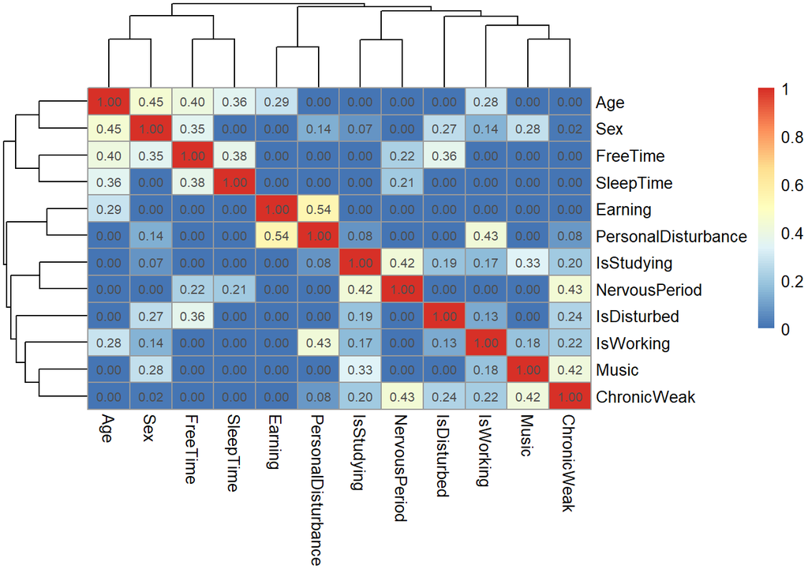

```r
library(pheatmap)
pheatmap(abs(corr_matrix), display_numbers = T)
```

```r
library(dplyr)
exogen_data <- dplyr::select(finished_data, -c("IsDisturbed", "PersonalDisturbance"))

exogen_data$Age <- (exogen_data$Age - mean(exogen_data$Age)) / sd(exogen_data$Age)
exogen_data$FreeTime <- (exogen_data$FreeTime - mean(exogen_data$FreeTime)) / sd(exogen_data$FreeTime)
exogen_data$SleepTime <- (exogen_data$SleepTime - mean(exogen_data$SleepTime)) / sd(exogen_data$SleepTime)


quant_col_names <- c("Age", "FreeTime", "SleepTime")
quant_cols <- exogen_data[, quant_col_names]
qual_cols <- dplyr::select(exogen_data, -quant_col_names)
```

```
## Note: Using an external vector in selections is ambiguous.
## i Use `all_of(quant_col_names)` instead of `quant_col_names` to silence this message.
## i See <https://tidyselect.r-lib.org/reference/faq-external-vector.html>.
```

```r
qual_cols_name <- colnames(qual_cols)
library(PCAmixdata)
pca_result <- PCAmix(
  X.quanti = quant_cols,
  X.quali = qual_cols,
  rename.level = TRUE,
  ndim = 5,
  graph = FALSE)
summary(pca_result)
```

```
##
## Call:
## PCAmix(X.quanti = quant_cols, X.quali = qual_cols, ndim = 5,     rename.level = TRUE, graph = FALSE)
##
## Method = Factor Analysis of mixed data (FAmix)
##
## Data:
##    number of observations:  47
##    number of  variables:  10
##         number of numerical variables:  3
##         number of categorical variables:  7
##
## Squared loadings :
##               dim 1 dim 2 dim 3 dim 4 dim 5
## Age            0.35  0.19  0.14  0.01  0.00
## FreeTime       0.22  0.27  0.00  0.00  0.02
## SleepTime      0.16  0.27  0.03  0.08  0.09
## Sex            0.26  0.17  0.08  0.19  0.00
## IsStudying     0.30  0.10  0.06  0.17  0.00
## IsWorking      0.15  0.12  0.44  0.00  0.00
## Music          0.34  0.26  0.21  0.21  0.56
## NervousPeriod  0.44  0.54  0.26  0.41  0.54
## ChronicWeak    0.07  0.39  0.00  0.11  0.12
## Earning        0.47  0.23  0.75  0.25  0.04
```

```r
last_finished_data <- finished_data
finished_data <- data.frame(
  pc1 = finished_data$Age*0.35
        + finished_data$FreeTime*0.22
        + finished_data$SleepTime*0.16
        + as.numeric(finished_data$Sex)*0.26
        + as.numeric(finished_data$IsStudying)*0.30
        + as.numeric(finished_data$IsWorking)*0.15
        + as.numeric(finished_data$Music)*0.34
        + as.numeric(finished_data$NervousPeriod)*0.44
        + as.numeric(finished_data$ChronicWeak)*0.07
        + as.numeric(finished_data$Earning)*0.47,
  pc2 = finished_data$Age*0.19
        + finished_data$FreeTime*0.27
        + finished_data$SleepTime*0.27
        + as.numeric(finished_data$Sex)*0.17
        + as.numeric(finished_data$IsStudying)*0.1
        + as.numeric(finished_data$IsWorking)*0.12
        + as.numeric(finished_data$Music)*0.26
        + as.numeric(finished_data$NervousPeriod)*0.54
        + as.numeric(finished_data$ChronicWeak)*0.39
        + as.numeric(finished_data$Earning)*0.23,
  pc3 = finished_data$Age*0.14
        + finished_data$FreeTime*0
        + finished_data$SleepTime*0.03
        + as.numeric(finished_data$Sex)*0.08
        + as.numeric(finished_data$IsStudying)*0.06
        + as.numeric(finished_data$IsWorking)*0.44
        + as.numeric(finished_data$Music)*0.21
        + as.numeric(finished_data$NervousPeriod)*0.26
        + as.numeric(finished_data$ChronicWeak)*0
        + as.numeric(finished_data$Earning)*0.75,
  pc4 = finished_data$Age*0.01
        + finished_data$FreeTime*0
        + finished_data$SleepTime*0.08
        + as.numeric(finished_data$Sex)*0.19
        + as.numeric(finished_data$IsStudying)*0.17
        + as.numeric(finished_data$IsWorking)*0
        + as.numeric(finished_data$Music)*0.21
        + as.numeric(finished_data$NervousPeriod)*0.41
        + as.numeric(finished_data$ChronicWeak)*0.11
        + as.numeric(finished_data$Earning)*0.25,
  pc5 = finished_data$Age*0
        + finished_data$FreeTime*0.02
        + finished_data$SleepTime*0.09
        + as.numeric(finished_data$Sex)*0
        + as.numeric(finished_data$IsStudying)*0
        + as.numeric(finished_data$IsWorking)*0
        + as.numeric(finished_data$Music)*0.56
        + as.numeric(finished_data$NervousPeriod)*0.54
        + as.numeric(finished_data$ChronicWeak)*0.12
        + as.numeric(finished_data$Earning)*0.04,
  PersonalDisturbance = finished_data$PersonalDisturbance)
```

### Построение модели

```r
split <- sample.split(finished_data$PersonalDisturbance, SplitRatio=0.7)
train <- subset(finished_data, split == TRUE)
test <- subset(finished_data, split == FALSE)
```

```r
summary(train$PersonalDisturbance)
```

```
## high  low
##   24    8
```

```r
library(caret)
train <- upSample(train[c("pc1", "pc2", "pc3", "pc4", "pc5")], y=train$PersonalDisturbance, yname="PersonalDisturbance")
summary(train$PersonalDisturbance)
```

```
## high  low
##   24   24
```

## Логит-модель

```r
model_l_c <- glm(PersonalDisturbance ~ pc1 + pc2 + pc3 + pc4 + pc5,
                 train,
                 family = binomial("logit"))
summary(model_l_c)
```

```
##
## Call:
## glm(formula = PersonalDisturbance ~ pc1 + pc2 + pc3 + pc4 + pc5,
##     family = binomial("logit"), data = train)
##
## Deviance Residuals:
##     Min       1Q   Median       3Q      Max
## -1.7084  -0.6539   0.1357   0.5394   1.6046
##
## Coefficients:
##             Estimate Std. Error z value Pr(>|z|)
## (Intercept)    2.497      4.749   0.526  0.59903
## pc1           -4.428      1.988  -2.227  0.02596 *
## pc2            3.376      1.627   2.075  0.03797 *
## pc3            5.677      2.309   2.459  0.01393 *
## pc4           -9.490      3.413  -2.781  0.00542 **
## pc5            3.542      1.769   2.002  0.04528 *
## ---
## Signif. codes:  0 '***' 0.001 '**' 0.01 '*' 0.05 '.' 0.1 ' ' 1
##
## (Dispersion parameter for binomial family taken to be 1)
##
##     Null deviance: 66.542  on 47  degrees of freedom
## Residual deviance: 43.908  on 42  degrees of freedom
## AIC: 55.908
##
## Number of Fisher Scoring iterations: 5
```

```r
model_l_n <- glm(PersonalDisturbance ~ 0 + pc1 + pc2 + pc3 + pc4 + pc5,
                 train,
                 family = binomial("logit"))
summary(model_l_n)
```

```
##
## Call:
## glm(formula = PersonalDisturbance ~ 0 + pc1 + pc2 + pc3 + pc4 +
##     pc5, family = binomial("logit"), data = train)
##
## Deviance Residuals:
##     Min       1Q   Median       3Q      Max
## -1.7516  -0.6004   0.1080   0.5508   1.6276
##
## Coefficients:
##     Estimate Std. Error z value Pr(>|z|)
## pc1   -4.549      1.984  -2.293  0.02184 *
## pc2    3.463      1.627   2.128  0.03333 *
## pc3    6.187      2.118   2.921  0.00349 **
## pc4   -9.834      3.321  -2.961  0.00306 **
## pc5    3.759      1.731   2.172  0.02987 *
## ---
## Signif. codes:  0 '***' 0.001 '**' 0.01 '*' 0.05 '.' 0.1 ' ' 1
##
## (Dispersion parameter for binomial family taken to be 1)
##
##     Null deviance: 66.542  on 48  degrees of freedom
## Residual deviance: 44.190  on 43  degrees of freedom
## AIC: 54.19
##
## Number of Fisher Scoring iterations: 5
```

Выберем модель на основе теста отношения максимального правдоподобия:  
H0 - упрощённая модель моделирует выборку лучше  
H1 - полная модель моделирует выборку лучше

```r
lr <- lrtest(model_l_c, model_l_n)
lr$Chisq[2]
```

```
## [1] 0.2823703
```

Критический хи-квадрат:

```r
qchisq(0.95, length(model_l_c$coefficients) - length(model_l_n$coefficients))
```

```
## [1] 3.841459
```

Как видим, наблюдаемое хи-квадрат меньше критического, а значит гипотеза о том, что упрощённая модель лучше комплексной принимается с уровнем значимости 0.05

```r
model_l <- model_l_n
```

## Пробит-модель

```r
model_p_c <- glm(PersonalDisturbance ~ pc1 + pc2 + pc3 + pc4 + pc5,
                 train,
                 family = binomial("probit"))
summary(model_p_c)
```

```
##
## Call:
## glm(formula = PersonalDisturbance ~ pc1 + pc2 + pc3 + pc4 + pc5,
##     family = binomial("probit"), data = train)
##
## Deviance Residuals:
##     Min       1Q   Median       3Q      Max
## -1.6952  -0.6383   0.1403   0.5115   1.5999
##
## Coefficients:
##             Estimate Std. Error z value Pr(>|z|)
## (Intercept)   1.3463     2.8069   0.480  0.63148
## pc1          -2.7854     1.1384  -2.447  0.01441 *
## pc2           2.1281     0.9356   2.275  0.02293 *
## pc3           3.5522     1.3217   2.688  0.00720 **
## pc4          -5.8361     1.9328  -3.020  0.00253 **
## pc5           2.1823     1.0367   2.105  0.03529 *
## ---
## Signif. codes:  0 '***' 0.001 '**' 0.01 '*' 0.05 '.' 0.1 ' ' 1
##
## (Dispersion parameter for binomial family taken to be 1)
##
##     Null deviance: 66.542  on 47  degrees of freedom
## Residual deviance: 43.328  on 42  degrees of freedom
## AIC: 55.328
##
## Number of Fisher Scoring iterations: 7
```

```r
model_p_n <- glm(PersonalDisturbance ~ 0 + pc1 + pc2 + pc3 + pc4 + pc5,
                 train,
                 family = binomial("probit"))
summary(model_p_n)
```

```
##
## Call:
## glm(formula = PersonalDisturbance ~ 0 + pc1 + pc2 + pc3 + pc4 +
##     pc5, family = binomial("probit"), data = train)
##
## Deviance Residuals:
##     Min       1Q   Median       3Q      Max
## -1.7358  -0.5850   0.1190   0.5198   1.6222
##
## Coefficients:
##     Estimate Std. Error z value Pr(>|z|)
## pc1  -2.8603     1.1340  -2.522  0.01166 *
## pc2   2.1822     0.9346   2.335  0.01955 *
## pc3   3.8429     1.1872   3.237  0.00121 **
## pc4  -6.0467     1.8697  -3.234  0.00122 **
## pc5   2.3050     1.0077   2.287  0.02217 *
## ---
## Signif. codes:  0 '***' 0.001 '**' 0.01 '*' 0.05 '.' 0.1 ' ' 1
##
## (Dispersion parameter for binomial family taken to be 1)
##
##     Null deviance: 66.542  on 48  degrees of freedom
## Residual deviance: 43.564  on 43  degrees of freedom
## AIC: 53.564
##
## Number of Fisher Scoring iterations: 7
```

Выберем модель на основе теста отношения максимального правдоподобия:  
H0 - упрощённая модель моделирует выборку лучше  
H1 - полная модель моделирует выборку лучше

```r
lrtest(model_p_c, model_p_n)$Chisq[2]
```

```
## [1] 0.2363442
```

```r
qchisq(0.95, length(model_p_c$coefficients) - length(model_p_n$coefficients))
```

```
## [1] 3.841459
```

Как видим, наблюдаемое хи-квадрат меньше критического, а значит гипотеза о том, что упрощённая модель лучше комплексной принимается с уровнем значимости 0.05

```r
model_p <- model_p_n
```

## Гомпит-модель

```r
model_g_c <- glm(PersonalDisturbance ~ pc1 + pc2 + pc3 + pc4 + pc5,
                 train,
                 family = binomial("cloglog"))
summary(model_g_c)
```

```
##
## Call:
## glm(formula = PersonalDisturbance ~ pc1 + pc2 + pc3 + pc4 + pc5,
##     family = binomial("cloglog"), data = train)
##
## Deviance Residuals:
##      Min        1Q    Median        3Q       Max
## -1.65673  -0.65571   0.01484   0.43097   1.60880
##
## Coefficients:
##             Estimate Std. Error z value Pr(>|z|)
## (Intercept)    1.137      3.316   0.343  0.73161
## pc1           -3.275      1.351  -2.424  0.01535 *
## pc2            2.508      1.110   2.260  0.02385 *
## pc3            4.099      1.612   2.542  0.01101 *
## pc4           -6.704      2.206  -3.039  0.00237 **
## pc5            2.511      1.143   2.197  0.02803 *
## ---
## Signif. codes:  0 '***' 0.001 '**' 0.01 '*' 0.05 '.' 0.1 ' ' 1
##
## (Dispersion parameter for binomial family taken to be 1)
##
##     Null deviance: 66.542  on 47  degrees of freedom
## Residual deviance: 43.408  on 42  degrees of freedom
## AIC: 55.408
##
## Number of Fisher Scoring iterations: 8
```

```r
model_g_n <- glm(PersonalDisturbance ~ 0 + pc1 + pc2 + pc3 + pc4 + pc5,
                 train,
                 family = binomial("cloglog"))
summary(model_g_n)
```

```
##
## Call:
## glm(formula = PersonalDisturbance ~ 0 + pc1 + pc2 + pc3 + pc4 +
##     pc5, family = binomial("cloglog"), data = train)
##
## Deviance Residuals:
##      Min        1Q    Median        3Q       Max
## -1.63287  -0.62835  -0.00929   0.42169   1.62661
##
## Coefficients:
##     Estimate Std. Error z value Pr(>|z|)
## pc1   -3.406      1.338  -2.545  0.01091 *
## pc2    2.613      1.102   2.371  0.01776 *
## pc3    4.380      1.440   3.041  0.00236 **
## pc4   -6.809      2.180  -3.124  0.00178 **
## pc5    2.556      1.138   2.246  0.02473 *
## ---
## Signif. codes:  0 '***' 0.001 '**' 0.01 '*' 0.05 '.' 0.1 ' ' 1
##
## (Dispersion parameter for binomial family taken to be 1)
##
##     Null deviance: 70.016  on 48  degrees of freedom
## Residual deviance: 43.554  on 43  degrees of freedom
## AIC: 53.554
##
## Number of Fisher Scoring iterations: 8
```

Проверим тестом правдоподобия какая модель лучше, со всеми экзогенными переменными или упрощённая: H0 - упрощённая модель моделирует выборку лучше  
H1 - полная модель моделирует выборку лучше

```r
lrtest(model_g_c, model_g_n)$Chisq[2]
```

```
## [1] 0.1461637
```

```r
qchisq(0.95, length(model_g_c$coefficients) - length(model_g_n$coefficients))
```

```
## [1] 3.841459
```

Как видим, наблюдаемое хи-квадрат меньше критического, а значит гипотеза о том, что упрощённая модель лучше комплексной принимается с уровнем значимости 0.05

```r
model_g <- model_g_n
```

### Выбор модели

## Нахождение информационных критериев

Для оценки моделей используются AIC, BIC, $R^2$ МакФаддена, тест отношения правдоподобия, критерий согласия Хосмера-Лемешоу, критерий Колмогорова-Смирнова и log-likelyhood.  
Заранее обозначим гипотезы для тестов:  
Критерий согласия Хосмера-Лемешоу:  
H0 - модель хорошо согласована с выборкой  
H1 - модель плохо согласована с выборкой  
Критерий Колмогорова-Смирнова:  
H0 - остатки распределены нормально  
H1 - остатки распределены не нормально

```r
AICs <- c(model_l$aic, model_p$aic, model_g$aic)

library(flexmix)
BICs <- c(BIC(model_l), BIC(model_p), BIC(model_g))

library(nnet)
LogLH <- c(logLik(model_l), logLik(model_p), logLik(model_g))

library(pscl)
pR2s <- c(pR2(model_l)["McFadden"], pR2(model_p)["McFadden"], pR2(model_g)["McFadden"])
```

```
## fitting null model for pseudo-r2
## fitting null model for pseudo-r2
## fitting null model for pseudo-r2
```

```r
library(vcdExtra)
hlTests <- c(HLtest(model_l, length(model_l$coefficients)+1)$p.value, HLtest(model_p, length(model_p$coefficients)+1)$p.value, HLtest(model_g, length(model_g$coefficients)+1)$p.value)

ks_pvalue_model_l <- ks.test(model_l$residuals, "pnorm", mean(model_l$residuals), sd(model_l$residuals))$p.value
ks_pvalue_model_p <- ks.test(model_p$residuals, "pnorm", mean(model_p$residuals), sd(model_p$residuals))$p.value
ks_pvalue_model_g <- ks.test(model_g$residuals, "pnorm", mean(model_g$residuals), sd(model_g$residuals))$p.value
ks_pvalues <- c(ks_pvalue_model_l, ks_pvalue_model_p, ks_pvalue_model_g)

info_crits <- data.frame(AICs, BICs, LogLH, hlTests, pR2s, ks_pvalues)
rownames(info_crits) <- c("Logit", "Probit", "Gompit")
info_crits
```

```
##            AICs     BICs     LogLH      hlTests      pR2s  ks_pvalues
## Logit  54.19042 63.54642 -22.09521 0.0005999893 0.3359032 0.022434010
## Probit 53.56420 62.92020 -21.78210 0.0006020465 0.3453141 0.163945640
## Gompit 53.55375 62.90975 -21.77687 0.0936879399 0.3454711 0.007983236
```

```r
model_upsample <- model_g
```

## Оценка построенной модели на основе графика QQ

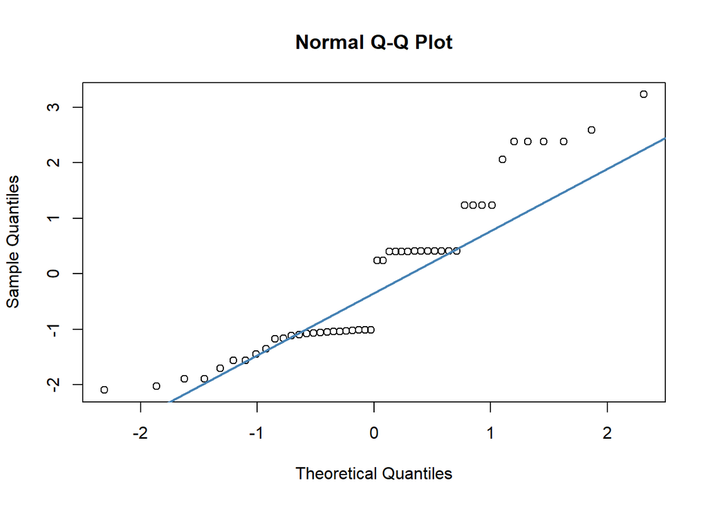

```r
qqnorm(model_upsample$residuals)
qqline(model_upsample$residuals, col="steelblue", lwd=2)
```

```r
test$predict <- predict(model_upsample, test, type='response')
test$predict <- as.factor(ifelse(test$predict < 0.4, "low", "high"))
confusionMatrix(data=test$predict, reference=test$PersonalDisturbance, positive="high")
```

```
## Confusion Matrix and Statistics
##
##           Reference
## Prediction high low
##       high    5   3
##       low     6   1
##
##                Accuracy : 0.4
##                  95% CI : (0.1634, 0.6771)
##     No Information Rate : 0.7333
##     P-Value [Acc > NIR] : 0.9986
##
##                   Kappa : -0.2385
##
##  Mcnemar's Test P-Value : 0.5050
##
##             Sensitivity : 0.4545
##             Specificity : 0.2500
##          Pos Pred Value : 0.6250
##          Neg Pred Value : 0.1429
##              Prevalence : 0.7333
##          Detection Rate : 0.3333
##    Detection Prevalence : 0.5333
##       Balanced Accuracy : 0.3523
##
##        'Positive' Class : high
##
```

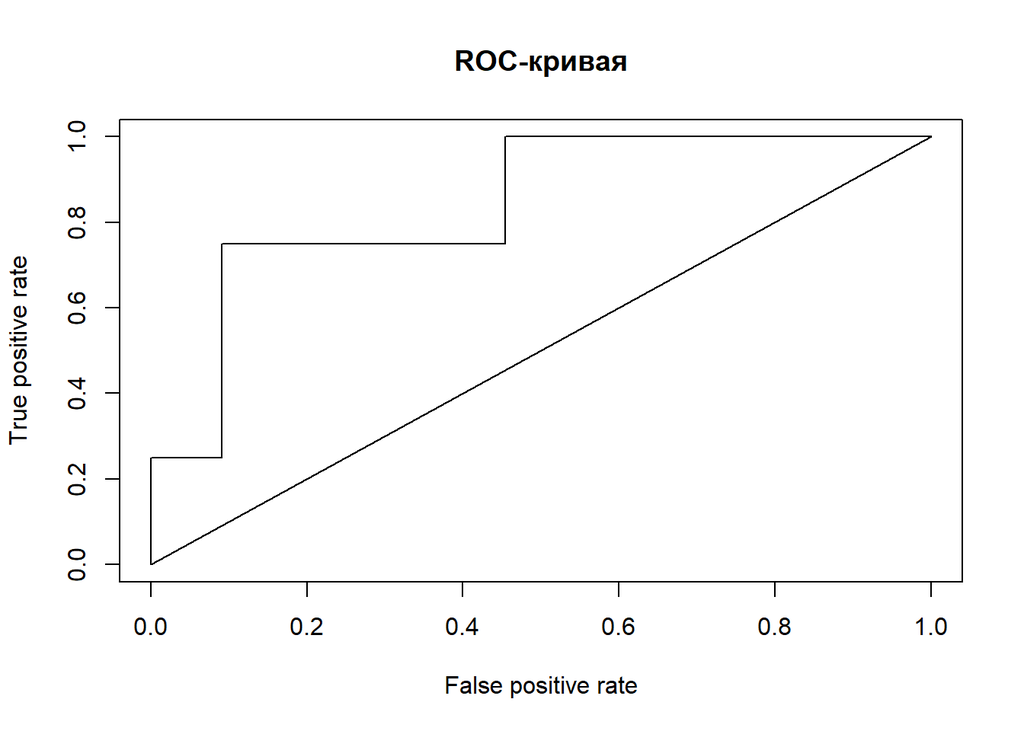

```r
library(ROCR)
pr <- prediction(predict(model_upsample, test, type='response'), as.numeric(test$PersonalDisturbance))
prf <- performance(pr, measure = "tpr", x.measure = "fpr")
plot(prf)
lines(c(0,1), c(0,1))
title("ROC-кривая")
```